# machine_learning_project

Tianming

1/22/2021

```r
library(tidyverse)
library(rpart)
library(caret)
library(xgboost)
library(randomForest)
```

## Data downloading

```r
Train_Url <- "https://d396qusza40orc.cloudfront.net/predmachlearn/pml-training.csv"
Test_Url <- "https://d396qusza40orc.cloudfront.net/predmachlearn/pml-testing.csv"

if(!file.exists("./data")){dir.create("./data")}
download.file(url = Train_Url, destfile = "./data/pml-training.csv", method = "curl")
download.file(url = Test_Url, destfile = "./data/pml-testing.csv", method = "curl")
```

## Data loading and preprocessing

```r
train_df <- read.csv(file = "./data/pml-training.csv", na.strings = c("NA", "#DIV/0", ""), header = T)
test_df <- read.csv(file = "./data/pml-testing.csv", na.strings = c("NA", "#DIV/0", ""), header = T)
# remove columns which only contain NAs
train_df <- train_df[, colSums(is.na(train_df)) == 0]
test_df <- test_df[, colSums(is.na(test_df)) == 0]
# remove unused columns
train_df <- train_df[, -c(1:7)]
test_df <- test_df[, -c(1:7)]

# summary of exercise classes
table(train_df$classe)
```

```
##
##    A    B    C    D    E
## 5580 3797 3422 3216 3607
```

## Class of exercise given the Note from original study

classA = specified execution of the exercise  
classB = throwing the elbows to the front  
classC = lifting the dumbbell only halfway  
classD = lowering the dumbbell only halfway  
classE = throwing the hips to the front

## Subset training dataset for modeling

```r
set.seed(123)
subsampling <- train_df$classe %>%
  createDataPartition(p = 0.8, list = FALSE)

df_train_sub <- train_df[subsampling, ]
df_test_sub <- train_df[-subsampling, ]
```

## Train with descision tree

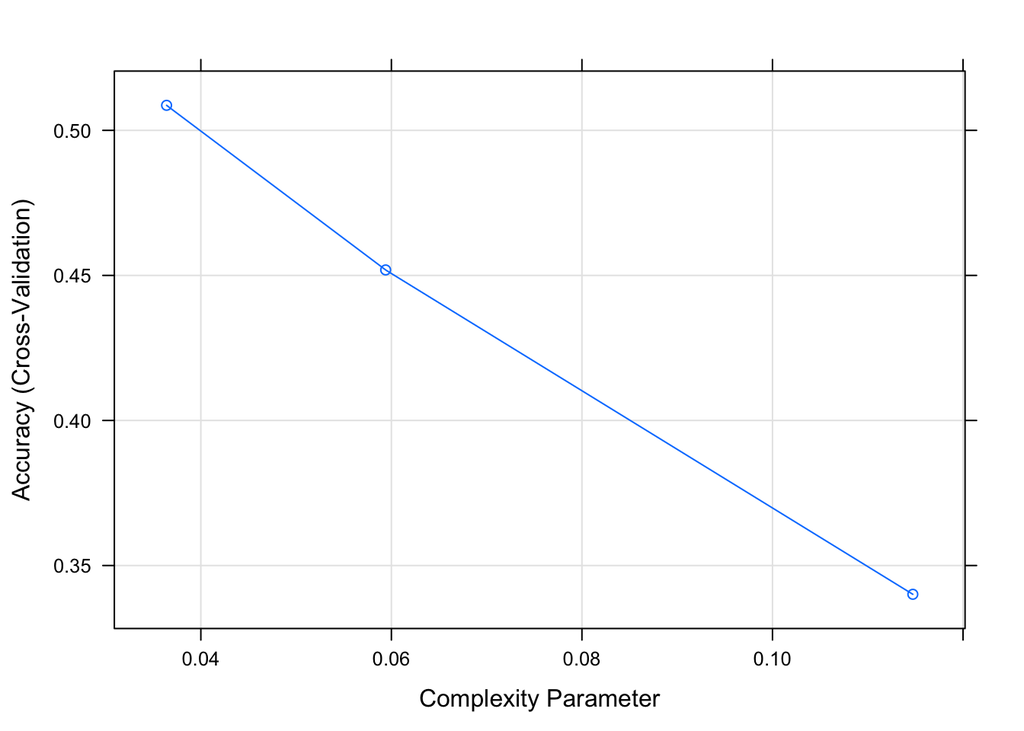

```r
set.seed(1988)
mod_rpart <- train(classe ~., data = df_train_sub, method = "rpart",
                   #set up 10-fold cross validation
                   trControl = trainControl("cv", number = 10))

# plot model accuracy vs different value of cp (complexity parameter)
plot(mod_rpart)
```

```r
mod_rpart$bestTune
```

```
##           cp
## 1 0.03640409
```

The best cp value is 0.036. The smaller the cp is, the higher chance we would get an overfitting model. Let’s test the predictions

## Accuracy of descision tree model

```r
pred_train_rpart <- predict(mod_rpart, df_test_sub)
cmModrpart <- confusionMatrix(pred_train_rpart, df_test_sub$classe)
# descision tree model accuracy
data.frame(Accuracy = cmModrpart$overall[1],
           RMSE = RMSE(as.numeric(pred_train_rpart), as.numeric(df_test_sub$classe)),
           R2 = R2(as.numeric(pred_train_rpart), as.numeric(df_test_sub$classe)))
```

```
##           Accuracy     RMSE        R2
## Accuracy 0.4996176 1.468854 0.3341143
```

```r
# observations vs predictions
cmModrpart$table
```

```
##           Reference
## Prediction    A    B    C    D    E
##          A 1012  309  302  274   95
##          B   18  258   21  119   92
##          C   85  192  361  250  205
##          D    0    0    0    0    0
##          E    1    0    0    0  329
```

49.96% accuracy is low, even though the predicted errors seem acceptable (RMSE = 1.47 and R2 = 0.33). From the table, we can also see many wrong predictions. Therefore we need try other modeling method for better modeling accuracy

## Train with Gradient Boosting model

```r
set.seed(2021)
modxgb <- train(classe ~., data = df_train_sub, method = "xgbTree",
                trControl = trainControl("cv", number = 10))


# Model Accuracy
pred_train_xgb <- predict(modxgb, df_test_sub)

cmModxgb <- confusionMatrix(pred_train_xgb, df_test_sub$classe)

data.frame(Accuracy = cmModxgb$overall[1],
           RMSE = RMSE(as.numeric(pred_train_xgb), as.numeric(df_test_sub$classe)),
           R2 = R2(as.numeric(pred_train_xgb), as.numeric(df_test_sub$classe)))
```

```
##           Accuracy      RMSE        R2
## Accuracy 0.9956666 0.0658287 0.9980103
```

```r
# Observations vs Predictions
cmModxgb$table
```

```
##           Reference
## Prediction    A    B    C    D    E
##          A 1113    3    0    0    0
##          B    3  754    0    0    0
##          C    0    2  683    4    0
##          D    0    0    1  639    4
##          E    0    0    0    0  717
```

## Conclusion

Above has shown that the gradient boosting model is the best one. The prediction of test data is as following

```r
predict(modxgb, newdata = test_df)
```

```
##  [1] B A B A A E D B A A B C B A E E A B B B
## Levels: A B C D E
```